# From Unconditional to Multivariate Bayesian Model Workshop – Series 1 of 10 – Gaussian vs Robust Estimation

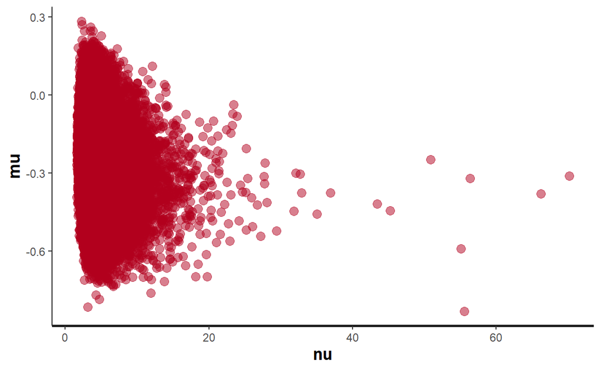

```r
stan_scat(stanFitRobust, c('nu','mu'))
```

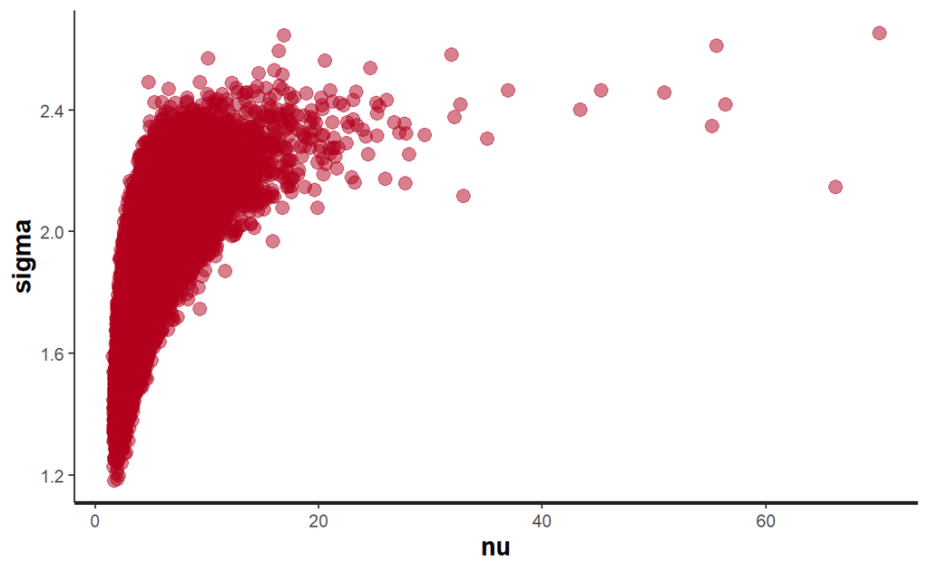

```r
stan_scat(stanFitRobust, c('nu','sigma'))
```

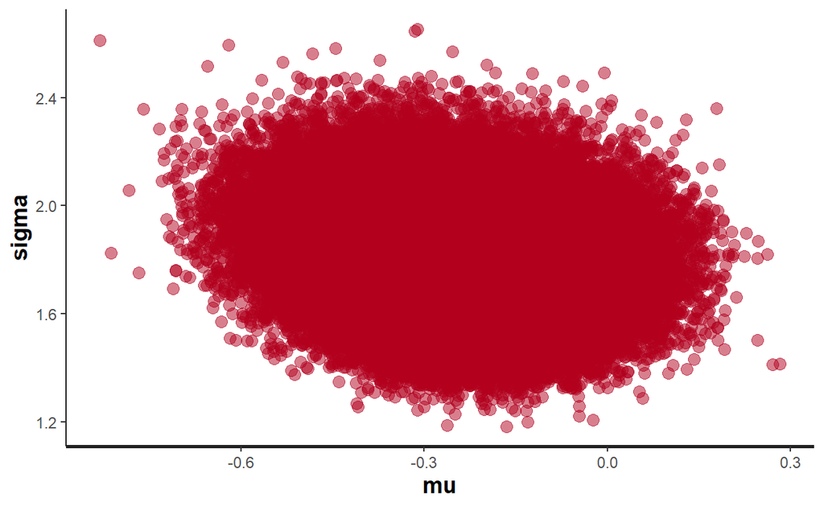

```r
stan_scat(stanFitRobust, c('mu','sigma'))
```

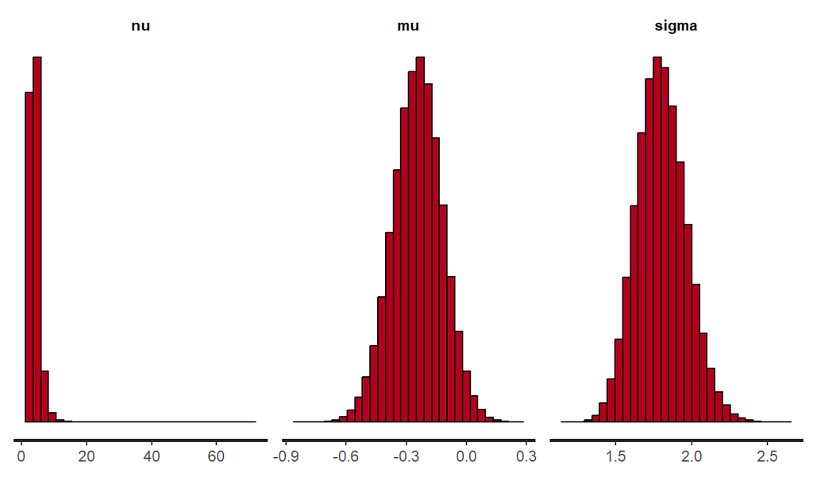

```r
stan_hist(stanFitRobust)
```

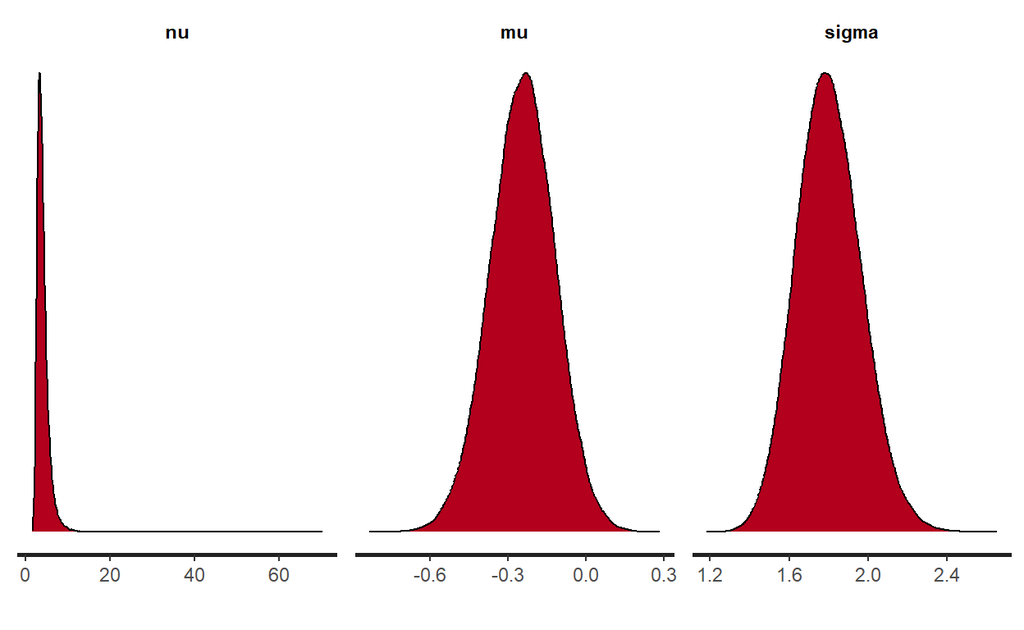

```r
stan_dens(stanFitRobust)
```

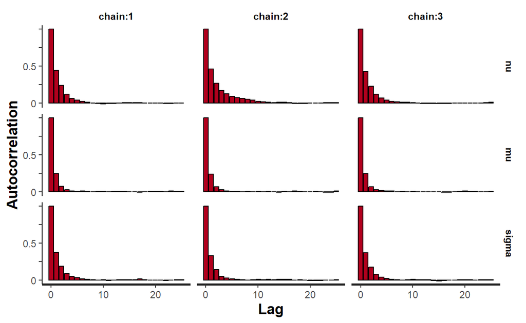

```r
# autocorrelation:
stan_ac(stanFitRobust, separate_chains = T)
```

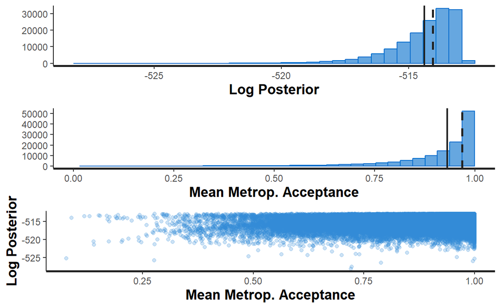

```r
stan_diag(stanFitRobust,information = "sample")
```

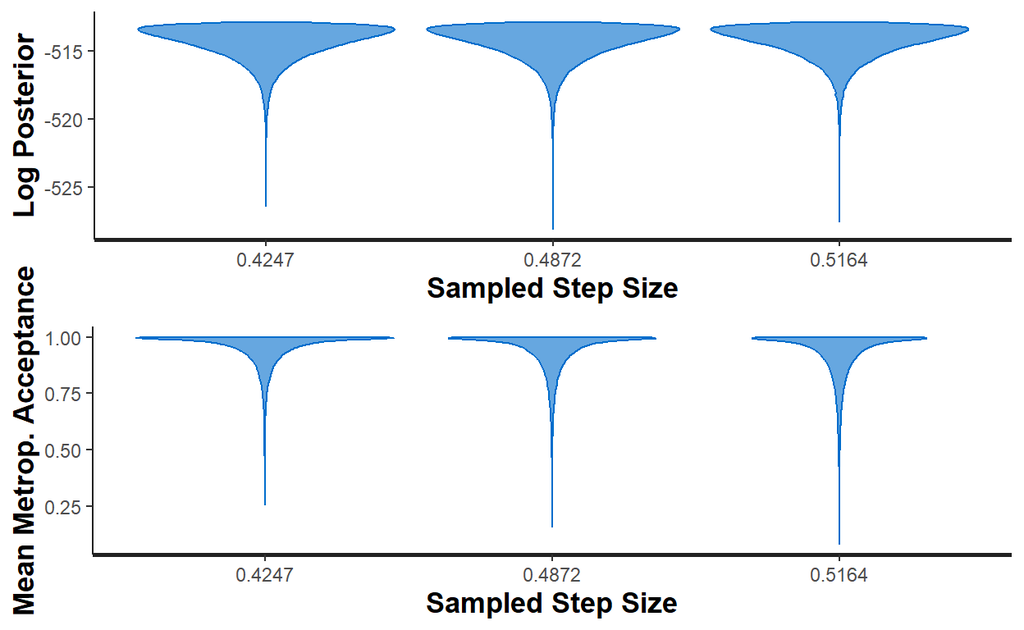

```r
stan_diag(stanFitRobust,information = "stepsize",chain = 0)
```

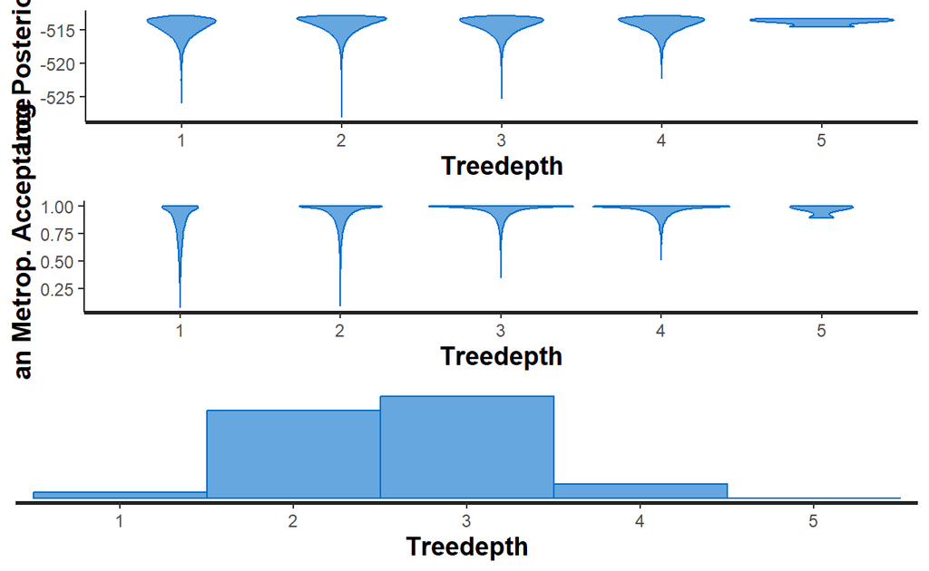

```r
stan_diag(stanFitRobust,information = "treedepth",chain = 0)
```

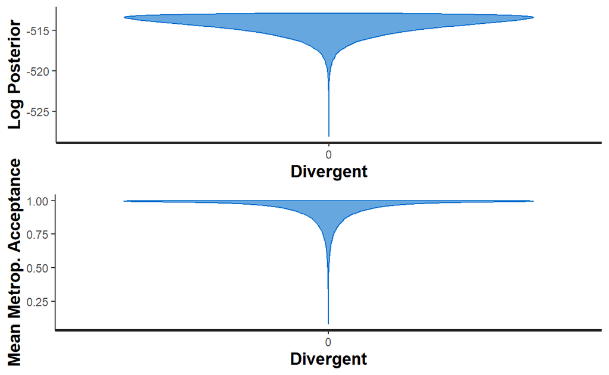

```r
stan_diag(stanFitRobust,information = "divergence",chain = 0)
```

There seems to be a pattern in relationship between $\sigma$ and $\nu$.  
Check if there is dependency.

```r
stanRobustChains <- extract(stanFitRobust)
names(stanRobustChains)
```

```
[1] "nu"    "mu"    "sigma" "lp__"
```

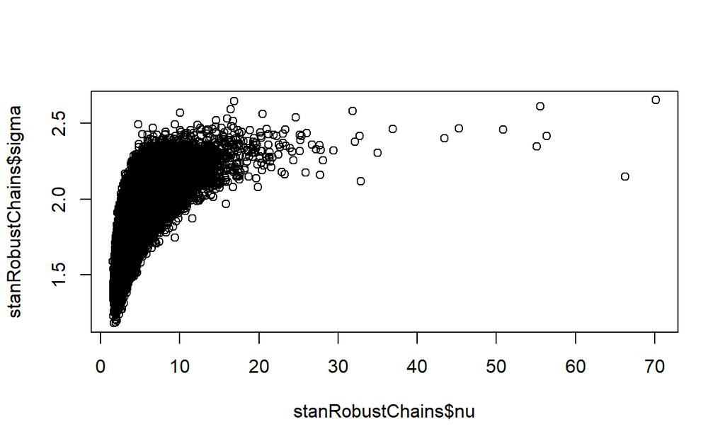

```r
plot(stanRobustChains$nu,stanRobustChains$sigma)
```

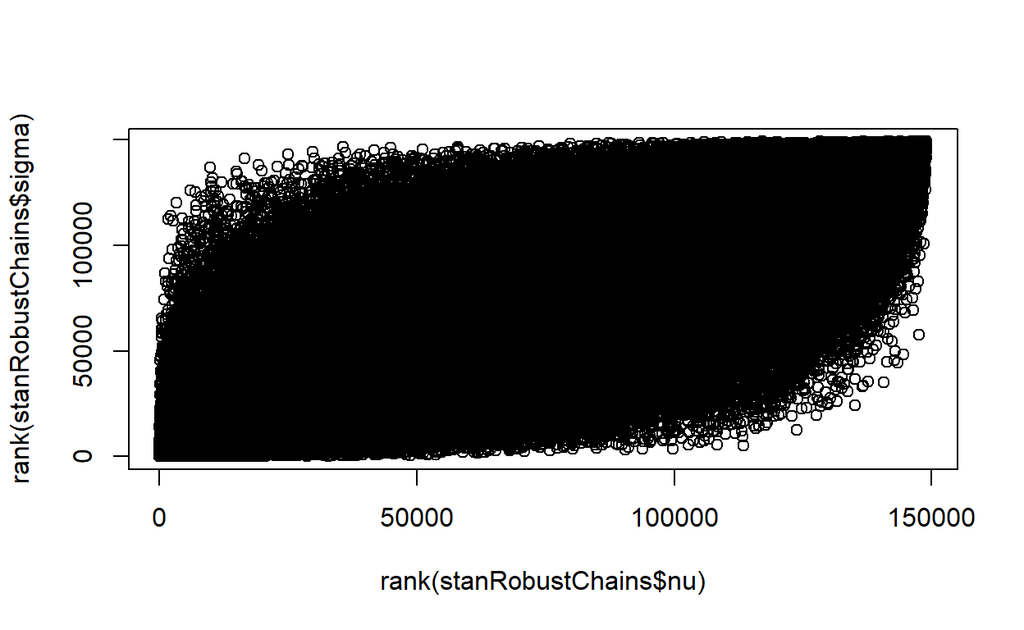

```r
plot(rank(stanRobustChains$nu),rank(stanRobustChains$sigma))
```

Interpret the dependency: Degrees of freedom $\nu$ are related to sample size $(n-1)$. If the df increases, it also stands that the sample size is increasing; the graph of the t-distribution will have skinnier tails, pushing the critical value towards the mean.

$\Rightarrow$ t-copulas (guess from empirical copulas)

Explore shiny object.

```r
launch_shinystan(stanFitRobust)
```

# Further reading

- Bayesian Methods, UC’s lecture
- Gelman, A., Carlin, J., Stern, H., Dunson, D., Vehtari, A., & Rubin, D. (2013). Bayesian Data Analysis, Third Edition, 3rd Edition (3rd edition ed.): CRC Press.
- Kutner, M. H. (2005). Applied linear statistical models (5th ed. ed.). Boston: McGraw-Hill Irwin.
- Kruschke, John K. Doing Bayesian Data Analysis: a Tutorial with R, JAGS, and Stan. 2nd ed., Academic Press is an imprint of Elsevier, 2015.